# 随机与抽样

Humoon

2021-08-03

[TOC]

## 设定随机数种子

有时我们在做模拟的时候，为了比较不同方法的好坏，需要生成的随机数都要一样，即重复生成同样的随机数。这个时候我们可以使用`set.seed()`设定随机数种子，其参数为整数。

```r
set.seed(123) # 种子取一样，生成的随机数相同
runif(5)
# [1] 0.2875775 0.7883051 0.4089769 0.8830174 0.9404673

runif(5) # 注意，运行语句本身就改变了种子！
# [1] 0.0455565 0.5281055 0.8924190 0.5514350 0.4566147

set.seed(123) # 重新设定种子，才能得到一样的结果2
runif(5)
# [1] 0.2875775 0.7883051 0.4089769 0.8830174 0.9404673
```

## 一元随机数的生成

### 常见分布函数表

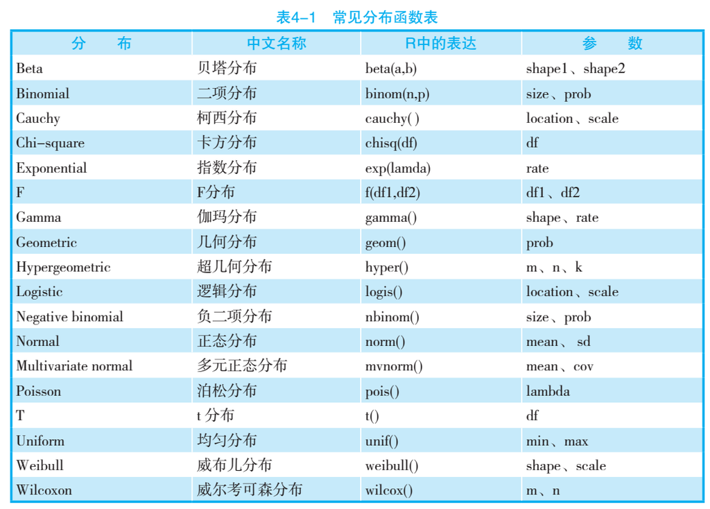

除了在分布函数前面加 r(random) 表示产生随机数外，还可以加 p(cumulative probability), q(quantile), d(density), 分别表示：

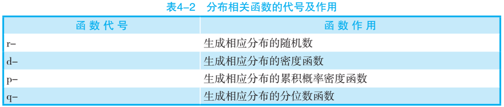

例如：`dnorm()` 表示正态分布密度函数，`pnorm()` 表示正态分布累积概率密度函数，`qnorm()` 表示正态分布分位数函数（即正态累积概率密度函数的逆函数)

```r
# 求标准正态分布P(x ≤ 2)的累积概率。
pnorm(2)
# [1] 0.9772499

# 已知标准正态分布累积概率为P(x≤a)=0.95，求对应的分位数a。
qnorm(0.95)
# [1] 1.644854
```

### 均匀分布

`runif(n, min = 0, max = 1)` 按照该参数的均匀分布，生成n个随机数

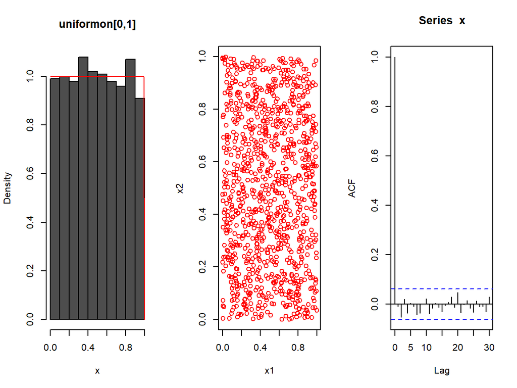

```r
# 通过直方图和散点图以及自相关系数图来检验独立同分布：
Nsim <- 10^3
x <- runif(Nsim)
x1 <- x[-Nsim] # 因为要计算自相关系数，去掉最后一个数
x2 <- x[-1] # 去掉第一个数
par(mfrow = c(1, 3))
# 图1 直方图
hist(x, prob = T, col = gray(0.3), main = "uniformon[0,1]")
curve(dunif(x, 0, 1), add = T, col = "red") # 添加均匀分布密度曲线
# 图2 散点图
plot(x1, x2, col = "red")
# 图3 自相关系数（时间序列分析）图
acf(x)
```

从上图可以看出，基本上满足独立同分布性质。

### 正态分布

`rnorm(n, mean=0, sd=1)` 按照该参数的正态分布，生成n个随机数

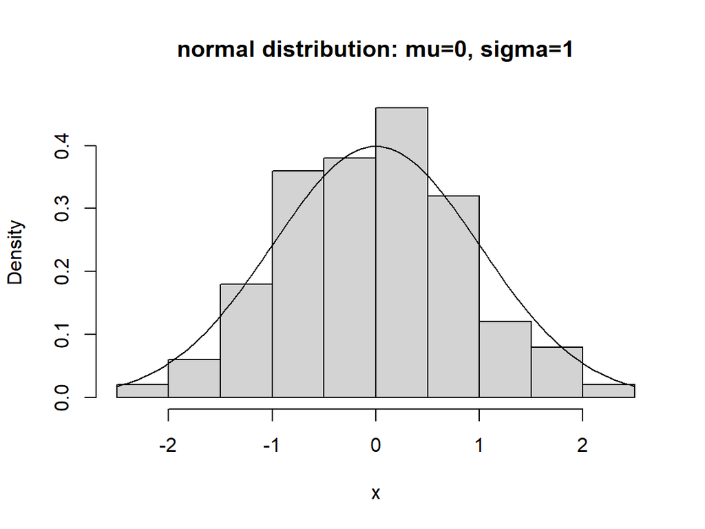

```r
# base plot
x <- rnorm(100)
hist(x, prob = T, main = "normal distribution: mu=0, sigma=1") # 作直方图
curve(dnorm(x), add = T) # 在直方图上添加标准正态分布密度曲线
```

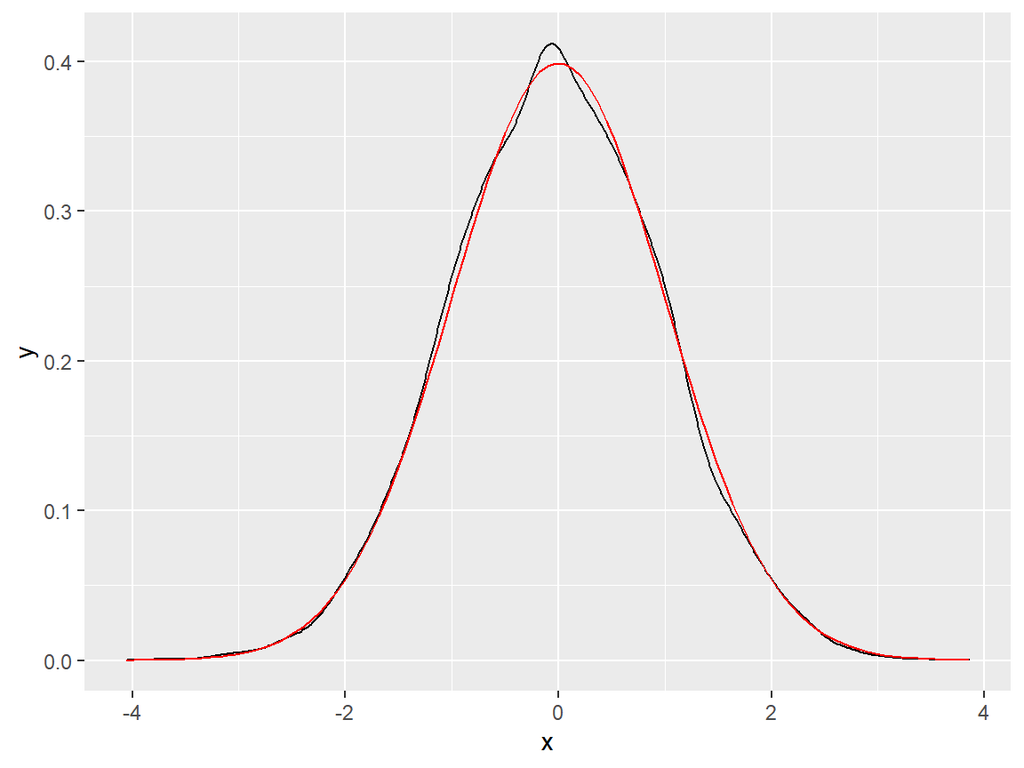

```r
# ggplot2
data.table(
  x = rnorm(10000)
) %>%
  ggplot(aes(x = x)) +
  geom_density() + # 实际分布
  # 理论正态分布
  stat_function(
    fun = dnorm,
    args = list(mean = 0, sd = 1),
    color = "red"
  )
```

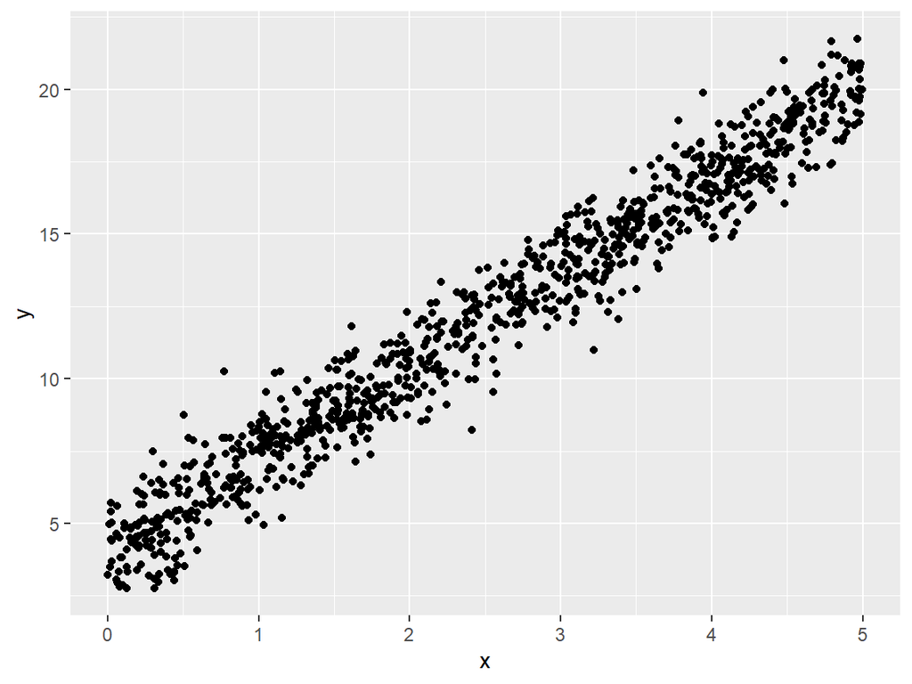

```r
# 线性关系模拟
a <- runif(1000, 0, 5)
b <- 4 + rnorm(1000, mean = 3.2 * a, sd = 1)
data.table(x = a, y = b) %>%
  ggplot(aes(x, y)) +
  geom_point()
```

### 指数分布

x 服从指数分布：$x \sim exp(\lambda)$，其中 $\lambda$ 等于均值的倒数。

`rexp(n, lamda=1)`

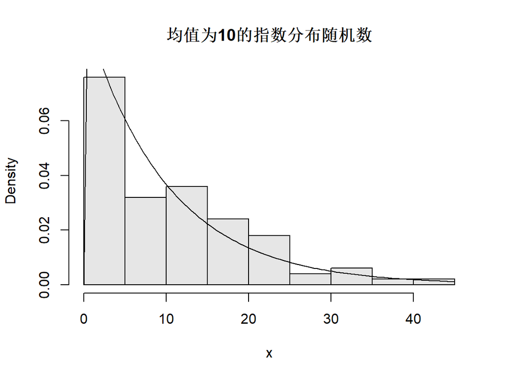

```r
x <- rexp(100, 1 / 10) # 生成100个均值为10的指数分布随机数
hist(x, prob = T, col = gray(0.9), main = "均值为10的指数分布随机数")
curve(dexp(x, 1 / 10), add = T) # 添加指数分布密度线
```

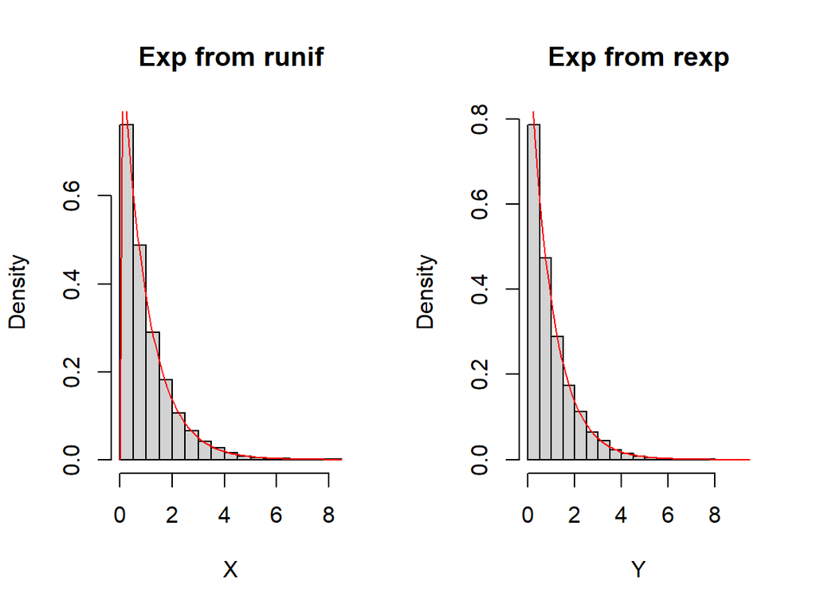

```r
# 比较两种方法生成的指数分布 X ~ Exp(1) 的随机数
Nsim <- 10^4
U <- runif(Nsim)
X <- -log(U)
Y <- rexp(Nsim)
par(mfrow = c(1, 2))
hist(X, freq = F, main = "Exp from runif")
curve(dexp(x, 1), add = T, col = "red")
hist(Y, freq = F, main = "Exp from rexp")
curve(dexp(x, 1), add = T, col = "red")
```

### 二项分布

x服从二项分布：$x \sim B(n, p)$

`rbinom(n,size,prob)`

n表示生成的随机数数量，size表示进行贝努力试验的次数，prob表示一次贝努力试验成功的概率。

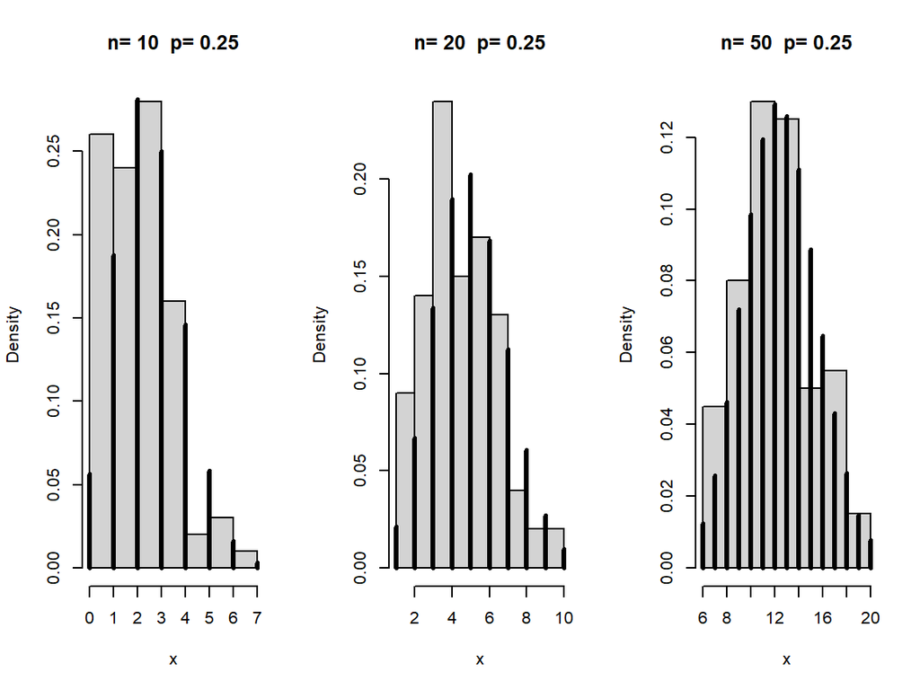

```r
size <- 1
p <- 0.5
rbinom(10, size, p) # 一次伯努利实验，p=0.5即抛硬币实验
#  [1] 0 1 1 0 1 1 0 1 0 0

size <- 10
p <- 0.5
rbinom(5, size, p) # 生成5个服从B(10,0.5)的二项分布随机数
# [1] 4 3 7 5 2

# 二项分布是离散分布，但随着试验次数size的增加，二项分布越来越接近于正态分布：
par(mfrow = c(1, 3))
p <- 0.25
for (k in c(10, 20, 50)) {
  x <- rbinom(100, size = k, p)
  hist(x, prob = T, main = paste("n=", k, " p=", p))
  xvals <- 0:k
  points(xvals, dbinom(xvals, k, p), type = "h", lwd = 3)
}
```

```r
par(mfrow = c(1, 1))
```

## 多元随机数的生成

### 多元正态分布随机数

#### MASS包

`MASS::mvrnorm(n=1,mu,Sigma,tol=1e-6,empirical=FALSE,EISPACK=FALSE)`

其中，n是生成的随机数个数，mu是均值向量，Sigma是协方差阵，tol是容忍度，empirical是逻辑参数，取TRUE时，mu和sigma取经验均值和协方差阵。

每组随机变量高度相关。 比如人的身高服从正态分布，人的体重也服从正态分布，同时身高和体重又存在强烈的关联。

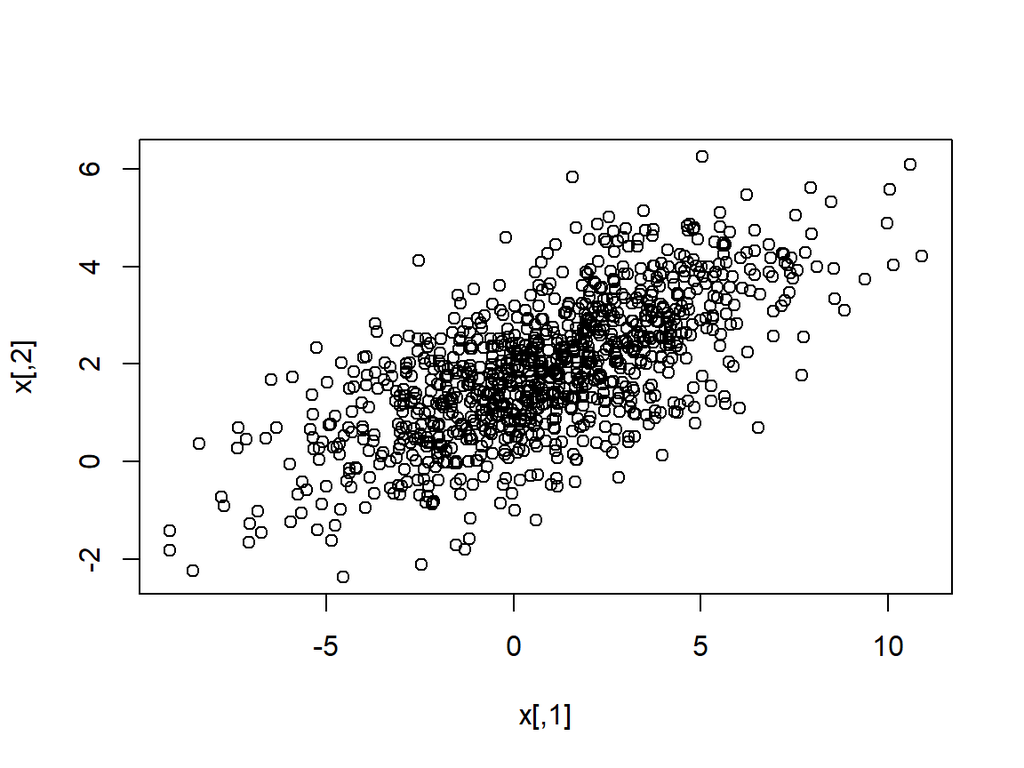

```r
library(MASS)
sigma <- matrix(c(10, 3, 3, 2), 2, 2)
mean <- c(1, 2)
x <- mvrnorm(n = 1000, mean, sigma)
head(x)
#            [,1]        [,2]
# [1,] -0.9955647  0.01959517
# [2,] -7.0746042 -1.64838409
# [3,] -2.7081002  0.13777741
# [4,] -1.5763108  1.39940023
# [5,]  3.5350813  0.94832129
# [6,] -1.0292258  0.77300844
var(x)
#           [,1]     [,2]
# [1,] 10.121044 3.026687
# [2,]  3.026687 2.000718
plot(x)
```

上图是两元正态分布随机数的散点图，从散点图可以看出，两个正态分布随机数是正相关关系。可以从协方差阵里算出相关系数是$\frac{3}{\sqrt{10\times 2}}$

$(x,y)$的协方差矩阵为为$\left( \begin{array}{cc}{\sigma_{1}^{2}} & {\rho \sigma_{1} \sigma_{2}} \\ {\rho \sigma_{1} \sigma_{2}} & {\sigma_{2}^{2}}\end{array}\right)$

#### mvtnorm包

`mvtnorm::rmvnorm(n, mean = rep(0, nrow(sigma)), sigma = diag(length(mean)), method=c("eigen", "svd", "chol"), pre0.9_9994 = FALSE)`

其中，n是生成随机数的个数，mean是均值向量，sigma是协方差阵。method提供了三种对sigma矩阵进行分解的方法：特征根分解“eign” （默认），奇异值分解“sv” ， cholesky分解“chol” 。

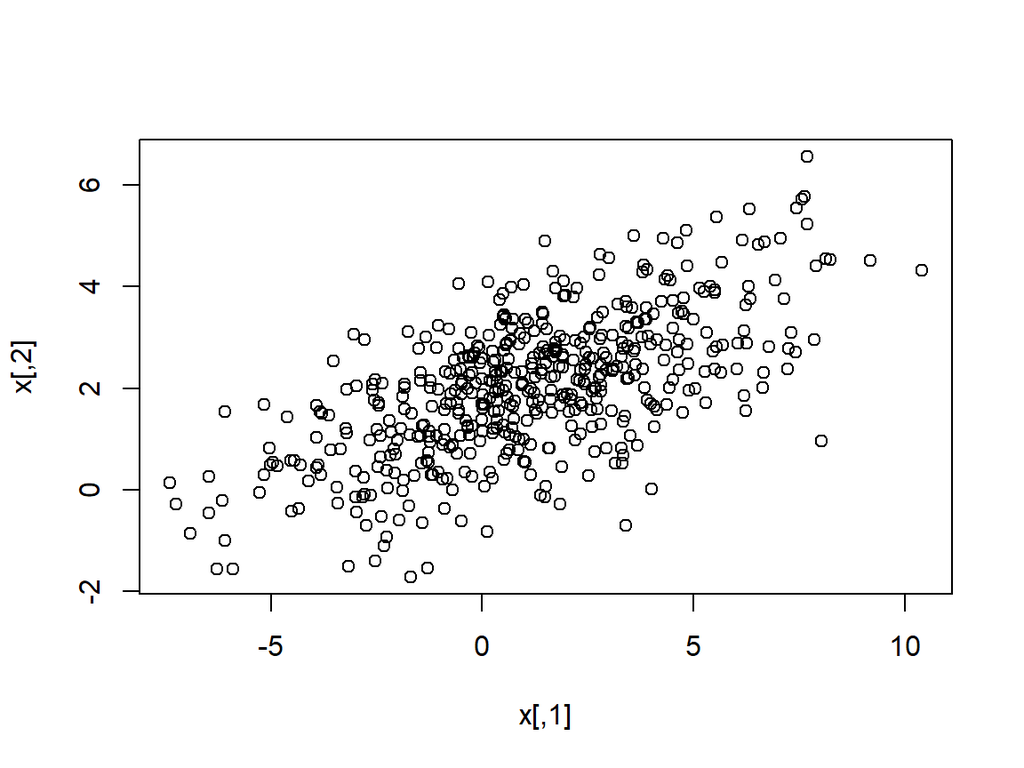

```r
library(mvtnorm)
x <- rmvnorm(n = 500, mean = mean, sigma = sigma)
head(x)
#            [,1]        [,2]
# [1,] -4.3324800 -0.36682647
# [2,]  2.5304704  2.61111275
# [3,]  1.8196643  2.42338068
# [4,]  2.2072520  0.97914135
# [5,]  4.0150174  0.01220865
# [6,] -0.8965101 -0.37754879
colMeans(x)
# [1] 1.109731 2.027425
var(x)
#          [,1]     [,2]
# [1,] 9.550706 2.764462
# [2,] 2.764462 1.922917
plot(x)
```

### 多元正态分布密度函数、分位数与累积概率

与生成一元随机数类似，mvtnorm::pmvnorm()可以计算累积概率，其用法是：

`pmvnorm(lower=-Inf, upper=Inf, mean=rep(0, length(lower)), corr=NULL, sigma=NULL, algorithm = GenzBretz(), ...)`

其中lower是求累积概率的下限，默认为$-\infty$。upper是求累积概率的上限，默认为$+\infty$。mean是多元正态分布的均值向量，corr是多元正态分布的相关系数矩阵，sigma是协方差矩阵。其中，相关系数矩阵和协方差矩阵两者只要知道一个即可。 algortithm是计算累积概率的算法，R提供了 GenzBretz、 Miwa 和 TVPACK，默认为 GenzBretz算法。

例：五元正态分布随机数，均值为0，相关系数矩阵为：
$$\left( \begin{array}{ccccc}{1} & {0.5} & {0.5} & {0.5} & {0.5} \\ {0.5} & {1} & {0.5} & {0.5} & {0.5} \\ {0.5} & {0.5} & {1} & {0.5} & {0.5} \\ {0.5} & {0.5} & {0.5} & {1} & {0.5} \\ {0.5} & {0.5} & {0.5} & {0.5} & {1}\end{array}\right)$$
求其下限为 (-1,-1,-1,-1,-1)，上限为 (3,3,3,3,3) 的累积概率。

```r
library(mvtnorm)
mean <- rep(0, 5) # 均值向量
lower <- rep(-1, 5) # 下
upper <- rep(3, 5) # 上限
corr <- diag(5) # 相关系数矩阵
corr[lower.tri(corr)] <- 0.5 # 相关系数矩阵下三角用0.5赋值
corr[upper.tri(corr)] <- 0.5 # 相关系数矩阵上三角用0.5赋值
corr
#      [,1] [,2] [,3] [,4] [,5]
# [1,]  1.0  0.5  0.5  0.5  0.5
# [2,]  0.5  1.0  0.5  0.5  0.5
# [3,]  0.5  0.5  1.0  0.5  0.5
# [4,]  0.5  0.5  0.5  1.0  0.5
# [5,]  0.5  0.5  0.5  0.5  1.0
(prob <- pmvnorm(lower, upper, mean, corr))
# [1] 0.5799506
# attr(,"error")
# [1] 0.0004006268
# attr(,"msg")
# [1] "Normal Completion"
```

同理，求多元正态分布的密度函数可以用dmvnorm()函数，求多元正态分布的分位数可以用qmvnorm()函数。

### 多元t分布随机数

多元t分布随机数：

`mvtnorm::rmvt(n, sigma = diag(2), df = 1, delta = rep(0, nrow(sigma)), type = c("shifted", "Kshirsagar"), ...)`

同理，求多元t分布的密度函数可以dmvt()函数，求多元t分布的分位数可以用qmvt()函数，求多元t分布的累积概率用pmvt()函数。

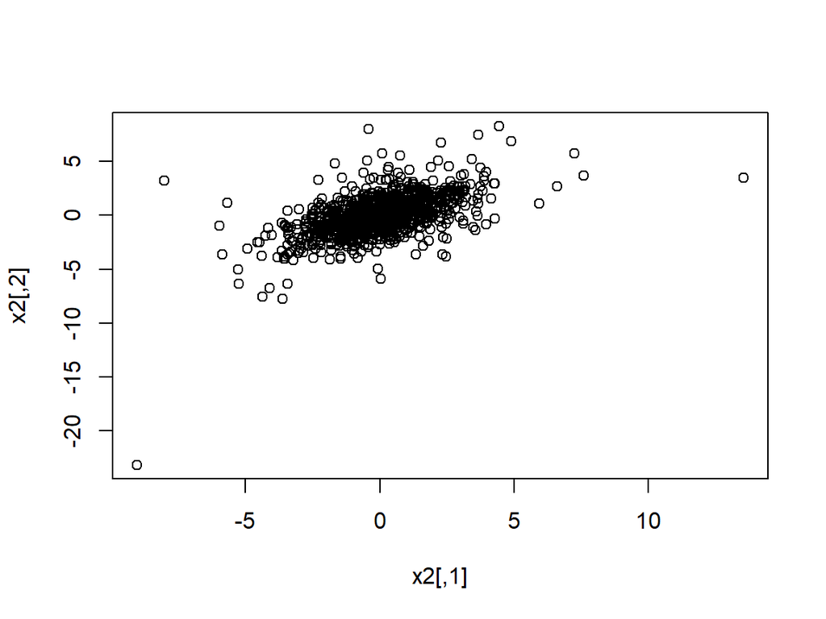

```r
# 生成1000个服从自由度为5，相关系数为0.5的两元t分布
library(mvtnorm)
sigma <- diag(2) + 1
sigma
#      [,1] [,2]
# [1,]    2    1
# [2,]    1    2
x2 <- rmvt(n = 1000, df = 5, sigma = sigma)
head(x2)
#            [,1]       [,2]
# [1,]  3.1920865  2.6436723
# [2,] -1.0627597  0.1128047
# [3,] -0.9991193 -1.8237971
# [4,]  1.8451699  1.6812570
# [5,] -2.1922141  0.9475836
# [6,]  3.1264194  2.1867959
plot(x2)
```

## 随机抽样

### 放回与无放回抽样

R可以进行有放回、无放回抽样。用R语言进行抽样很简单，只要用sample()函数就可以。其语法为：

`sample(x,n,replace=F,prob=NULL)`

其中，X表示总体向量。n表示样本容量，replace=F 表示无放回抽样，replace=T 表示有放回抽样。prob 可以设置各个抽样单元不同的入样概率，进行不等概率抽样。

```r
# 用R来模拟抛一枚硬币，H表示正面，T表示反面，重复抛10次的情况。
sample(c("H", "T"), 10, rep = T)
#  [1] "T" "T" "H" "H" "T" "T" "T" "T" "H" "T"
# 掷一颗六面的骰子，重复掷10次。
sample(1:6, 10, rep = T)
#  [1] 3 6 6 2 1 4 1 2 1 2
# 从100个产品中无放回随机抽取10个
sample(100, 10)
#  [1] 69 42 23 78  2  4 18 29 72 94

# 掷两颗六面的骰子，重复5次（的抽样）
dice <- as.vector(outer(1:6, 1:6, paste))
sample(dice, 5, replace = T)
# [1] "5 4" "1 3" "3 3" "6 1" "1 4"
# 掷两颗六面的骰子所有可能的结果
dice <- as.vector(outer(1:6, 1:6, paste))
dice
#  [1] "1 1" "2 1" "3 1" "4 1" "5 1" "6 1" "1 2" "2 2" "3 2" "4 2" "5 2" "6 2"
# [13] "1 3" "2 3" "3 3" "4 3" "5 3" "6 3" "1 4" "2 4" "3 4" "4 4" "5 4" "6 4"
# [25] "1 5" "2 5" "3 5" "4 5" "5 5" "6 5" "1 6" "2 6" "3 6" "4 6" "5 6" "6 6"
```

注：这里outer（a,b,function），当function为空时，表示a，b两个向量的外积，也就等价于a %o% b。function是paste表示X向量的第一个元素与Y向量的**每个**元素分别组合，组成第一行，接着，X向量的第二个元素与Y向量的**每个**元素分别组合，组成第二行，直到X向量最后一个元素组合完毕。由于这时为矩阵形式，用as.vector()把X强制转换成向量形式。

```r
outer(letters[1:6], 1:6, paste)
#      [,1]  [,2]  [,3]  [,4]  [,5]  [,6]
# [1,] "a 1" "a 2" "a 3" "a 4" "a 5" "a 6"
# [2,] "b 1" "b 2" "b 3" "b 4" "b 5" "b 6"
# [3,] "c 1" "c 2" "c 3" "c 4" "c 5" "c 6"
# [4,] "d 1" "d 2" "d 3" "d 4" "d 5" "d 6"
# [5,] "e 1" "e 2" "e 3" "e 4" "e 5" "e 6"
# [6,] "f 1" "f 2" "f 3" "f 4" "f 5" "f 6"
```